# Data Analysis on CEO Dataset

2023-11-14

```r
#Stop / hide warnings
options(warn = -1)
```

```r
# Import required libraries
library(tidyverse)
library(finetune)
library(tidytuesdayR)
library(vip)
library(tidymodels)
library(textrecipes)
library(embed)
library(themis)
library(parsnip)
library(rsample)
library(doParallel)
```

```r
library(ggrepel)
library(dplyr)
library(ggplot2)
library(tidytext) # for tokenization
library(tidylo)   # for bind_log_odds
library(broom)
```

```r
#mport the dataset

departures_raw <- readr::read_csv("https://raw.githubusercontent.com/rfordatascience/tidytuesday/master/data/2021/2021-04-27/departures.csv", show_col_types=FALSE)
```

DATA WRANGLING:

```r
#explore the dataset
departures_raw
```

```
## # A tibble: 9,423 × 19
##    dismissal_dataset_id coname              gvkey fyear co_per_rol exec_fullname
##                   <dbl> <chr>               <dbl> <dbl>      <dbl> <chr>
##  1               559043 SONICBLUE INC       27903  2002         -1 L. Gregory B…
##  2                   12 AMERICAN AIRLINES …  1045  1997          1 Robert L. Cr…
##  3                   13 AMERICAN AIRLINES …  1045  2002          3 Donald J. Ca…
##  4                   31 ABBOTT LABORATORIES  1078  1998          6 Duane L. Bur…
##  5                   43 ADVANCED MICRO DEV…  1161  2001         11 Walter Jerem…
##  6                   51 AETNA INC            1177  1997         16 Ronald Edwar…
##  7                   61 AHMANSON (H F) & CO  1194  1993         21 Richard H. D…
##  8                   63 AHMANSON (H F) & CO  1194  1997         22 Charles R. R…
##  9                   62 AHMANSON (H F) & CO  1194  1993         24 Robert M. De…
## 10                   65 AIR PRODUCTS & CHE…  1209  2000         28 Harold A. Wa…
## # ℹ 9,413 more rows
## # ℹ 13 more variables: departure_code <dbl>, ceo_dismissal <dbl>,
## #   interim_coceo <chr>, tenure_no_ceodb <dbl>, max_tenure_ceodb <dbl>,
## #   fyear_gone <dbl>, leftofc <dttm>, still_there <chr>, notes <chr>,
## #   sources <chr>, eight_ks <chr>, cik <dbl>, `_merge` <chr>
```

```r
#Checking Null values
apply(departures_raw,2,function(x) sum(is.na(x)))
```

```
## dismissal_dataset_id               coname                gvkey
##                    0                    0                    0
##                fyear           co_per_rol        exec_fullname
##                    0                    0                    0
##       departure_code        ceo_dismissal        interim_coceo
##                 1667                 1813                 9105
##      tenure_no_ceodb     max_tenure_ceodb           fyear_gone
##                    0                    0                 1802
##              leftofc          still_there                notes
##                 1802                 7311                 1644
##              sources             eight_ks                  cik
##                 1475                 4499                  245
##               _merge
##                    0
```

```r
# check count for unique departure code
departures_raw %>% count(departure_code)
```

```
## # A tibble: 10 × 2
##    departure_code     n
##             <dbl> <int>
##  1              1    84
##  2              2    97
##  3              3  1320
##  4              4   195
##  5              5  3598
##  6              6   183
##  7              7  2133
##  8              8    53
##  9              9    93
## 10             NA  1667
```

```r
#filter na values
departures_raw%>% filter (is.na(departure_code))
```

```
## # A tibble: 1,667 × 19
##    dismissal_dataset_id coname              gvkey fyear co_per_rol exec_fullname
##                   <dbl> <chr>               <dbl> <dbl>      <dbl> <chr>
##  1                  118 HESS CORP            1380  2019         79 John B. Hess
##  2                  345 BALLY ENTERTAINMEN…  1990  1995        252 Arthur M. Go…
##  3                  854 COMCAST CORP         3226  2017        581 Brian L. Rob…
##  4                 1085 DILLARDS INC -CL A   3964  2017        754 William T. D…
##  5                 1178 E-SYSTEMS INC        4159  1994        818 A. Lowell La…
##  6                 1299 FEDEX CORP           4598  2016        885 Frederick W.…
##  7                 2081 L BRANDS INC         6733  2017       1329 Leslie H. We…
##  8                  149 AFLAC INC            1449  2019       2653 Daniel Paul …
##  9                  229 NABORS INDUSTRIES …  1661  2019       2680 Anthony G. P…
## 10                11399 FLOWERS FOODS INC    4809  2019       3185 A. Ryals McM…
## # ℹ 1,657 more rows
## # ℹ 13 more variables: departure_code <dbl>, ceo_dismissal <dbl>,
## #   interim_coceo <chr>, tenure_no_ceodb <dbl>, max_tenure_ceodb <dbl>,
## #   fyear_gone <dbl>, leftofc <dttm>, still_there <chr>, notes <chr>,
## #   sources <chr>, eight_ks <chr>, cik <dbl>, `_merge` <chr>
```

```r
#create a new dataframe for filtered departure code
departures<-departures_raw %>%
  filter(departure_code < 8)
```

```r
#view the data
departures
```

```
## # A tibble: 7,610 × 19
##    dismissal_dataset_id coname              gvkey fyear co_per_rol exec_fullname
##                   <dbl> <chr>               <dbl> <dbl>      <dbl> <chr>
##  1               559043 SONICBLUE INC       27903  2002         -1 L. Gregory B…
##  2                   12 AMERICAN AIRLINES …  1045  1997          1 Robert L. Cr…
##  3                   13 AMERICAN AIRLINES …  1045  2002          3 Donald J. Ca…
##  4                   31 ABBOTT LABORATORIES  1078  1998          6 Duane L. Bur…
##  5                   43 ADVANCED MICRO DEV…  1161  2001         11 Walter Jerem…
##  6                   51 AETNA INC            1177  1997         16 Ronald Edwar…
##  7                   61 AHMANSON (H F) & CO  1194  1993         21 Richard H. D…
##  8                   63 AHMANSON (H F) & CO  1194  1997         22 Charles R. R…
##  9                   65 AIR PRODUCTS & CHE…  1209  2000         28 Harold A. Wa…
## 10                   75 ALBERTO-CULVER CO    1239  1993         33 Leonard H. L…
## # ℹ 7,600 more rows
## # ℹ 13 more variables: departure_code <dbl>, ceo_dismissal <dbl>,
## #   interim_coceo <chr>, tenure_no_ceodb <dbl>, max_tenure_ceodb <dbl>,
## #   fyear_gone <dbl>, leftofc <dttm>, still_there <chr>, notes <chr>,
## #   sources <chr>, eight_ks <chr>, cik <dbl>, `_merge` <chr>
```

```r
#Checking Null values
apply(departures,2,function(x) sum(is.na(x)))
```

```
## dismissal_dataset_id               coname                gvkey
##                    0                    0                    0
##                fyear           co_per_rol        exec_fullname
##                    0                    0                    0
##       departure_code        ceo_dismissal        interim_coceo
##                    0                    0                 7318
##      tenure_no_ceodb     max_tenure_ceodb           fyear_gone
##                    0                    0                  132
##              leftofc          still_there                notes
##                  132                 7101                   18
##              sources             eight_ks                  cik
##                   11                 2775                  224
##               _merge
##                    0
```

```r
#drop variables with too much missing values and also drop reduntant columns
departures<- departures%>%
  select(-still_there, -interim_coceo,-eight_ks, - cik,- '_merge', -ceo_dismissal, -sources, -leftofc, -gvkey, -co_per_rol)
```

```r
#Checking Null values
apply(departures,2,function(x) sum(is.na(x)))
```

```
## dismissal_dataset_id               coname                fyear
##                    0                    0                    0
##        exec_fullname       departure_code      tenure_no_ceodb
##                    0                    0                    0
##     max_tenure_ceodb           fyear_gone                notes
##                    0                  132                   18
```

```r
#view the data
departures
```

```
## # A tibble: 7,610 × 9
##    dismissal_dataset_id coname                fyear exec_fullname departure_code
##                   <dbl> <chr>                 <dbl> <chr>                  <dbl>
##  1               559043 SONICBLUE INC          2002 L. Gregory B…              7
##  2                   12 AMERICAN AIRLINES GR…  1997 Robert L. Cr…              5
##  3                   13 AMERICAN AIRLINES GR…  2002 Donald J. Ca…              3
##  4                   31 ABBOTT LABORATORIES    1998 Duane L. Bur…              5
##  5                   43 ADVANCED MICRO DEVIC…  2001 Walter Jerem…              5
##  6                   51 AETNA INC              1997 Ronald Edwar…              5
##  7                   61 AHMANSON (H F) & CO    1993 Richard H. D…              5
##  8                   63 AHMANSON (H F) & CO    1997 Charles R. R…              7
##  9                   65 AIR PRODUCTS & CHEMI…  2000 Harold A. Wa…              5
## 10                   75 ALBERTO-CULVER CO      1993 Leonard H. L…              5
## # ℹ 7,600 more rows
## # ℹ 4 more variables: tenure_no_ceodb <dbl>, max_tenure_ceodb <dbl>,
## #   fyear_gone <dbl>, notes <chr>
```

```r
#categorical variable encoding
ceo_departures <- departures %>%
  mutate(
    departure_category = case_when(
      departure_code <= 4 ~ "Involuntary",
      between(departure_code, 5, 6) ~ "Voluntary",
      departure_code >= 7 ~ "Other",
    )) %>%

    # Treat dismissal_dataset_id
    mutate(dismissal_dataset_id = as.character(dismissal_dataset_id)) %>%
    distinct(dismissal_dataset_id, .keep_all = TRUE) %>%

    # Convert to factor the variables with a few unique values
    mutate(across(tenure_no_ceodb:fyear_gone, factor)) %>%

    # Convert to factor all character variables, except the string variable - notes
    mutate(across(where(is.character), factor)) %>%

    # Keep notes as character
    mutate(notes = as.character(notes)) %>%
    filter(!is.na(notes))
```

```r
#check unique departure category count
ceo_departures %>% count(departure_category)
```

```
## # A tibble: 3 × 2
##   departure_category     n
##   <fct>              <int>
## 1 Involuntary         1693
## 2 Other               2126
## 3 Voluntary           3771
```

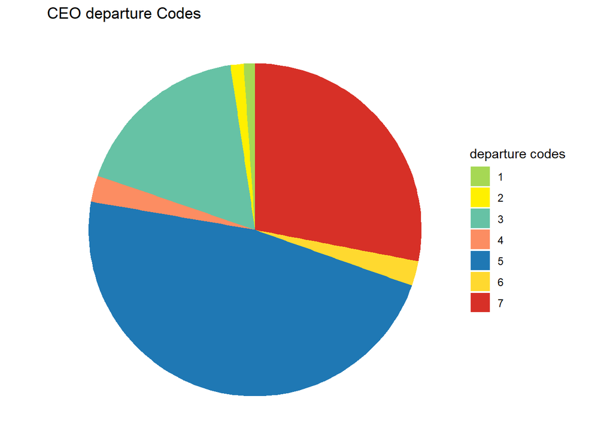

```r
# Create a data frame with the counts
departure_counts <- as.data.frame(table(departures$departure_code))

#Plot pie chart for departure code
my_colors <- c("#a6d854", "#fff000","#66c2a5" ,"#fc8d62","#1f78b4", "#ffd92f","#d73027", "#e78ac3")

# Create a pie chart using ggplot2 with custom color palette
ggplot(departure_counts, aes(x = "", y = Freq, fill = Var1)) +
  geom_bar(stat = "identity", width = 1)+
  coord_polar("y") +
  theme_void() +
  scale_fill_manual(values = my_colors) +  # Custom color palette
  ggtitle("CEO departure Codes") +
   labs(fill = "departure codes")
```

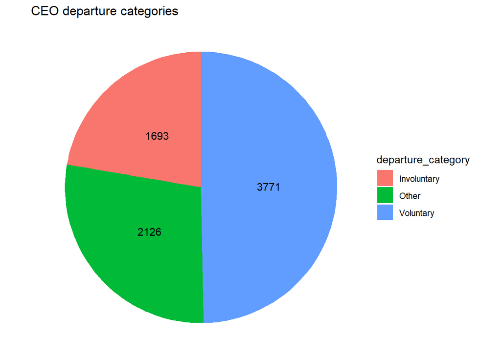

```r
#plot departure categories

ceo_departures %>%
  group_by(departure_category) %>%
  summarize(count = n()) %>%
  ggplot(aes(x = "", y = count, fill = departure_category)) +
  geom_bar(stat = "identity", width = 1) +
  geom_text(aes(label=count),position =position_stack(vjust=0.5))+
  coord_polar("y", start = 0) +
  theme_void() +  # Removes unnecessary elements like axes and labels
  theme(legend.position = "right") +
  ggtitle("CEO departure categories")
```

EXPLORATORY DATA ANALYSIS:

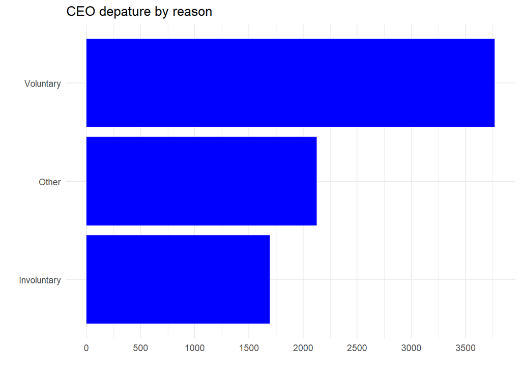

```r
#plot CEO departure by reason
ceo_departures %>%
   group_by(departure_category) %>%
   count() %>%
   ggplot(aes(y = fct_reorder(departure_category, n), x = n)) +
   geom_col(fill = "blue") +
   labs(
      title = "CEO depature by reason",
      x = "",
      y = "",
   ) +
   scale_x_continuous(breaks = scales::breaks_width(500))+theme_minimal()
```

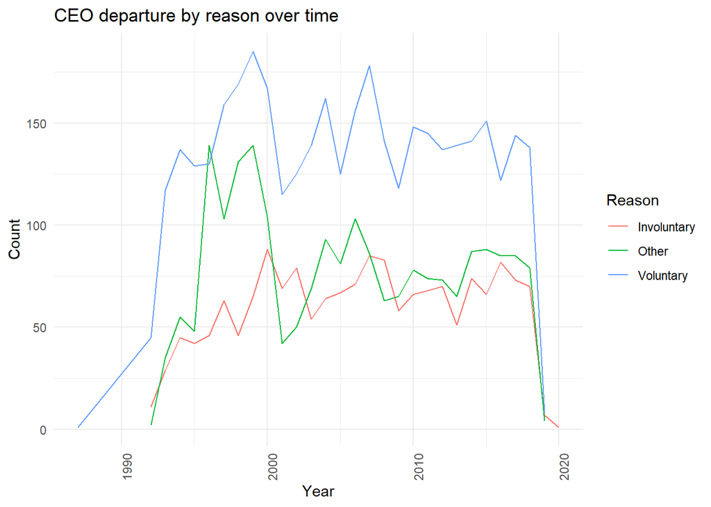

```r
#plot departure category by reason over time
ceo_departures %>%
  group_by(fyear,departure_category) %>%
  count() %>%
  ggplot(aes(x = fyear, y = n, color = departure_category, group = departure_category)) +
  geom_line() +
  labs(
    title = "CEO departure by reason over time",
    color = "Reason",
    y     = "Count",
    x     = "Year"
  ) +
  theme_minimal()+
  theme(axis.text.x = element_text(angle = 90, hjust = 1))
```

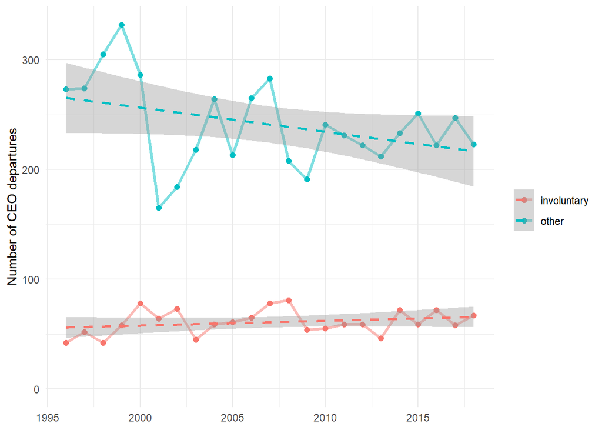

```r
#Plot departure category (voluntary and involuntary) count  by year
departures_raw%>%
  filter(departure_code < 9) %>%
  mutate(involuntary = if_else(departure_code %in% 3:4, "involuntary", "other")) %>%
  filter(fyear > 1995, fyear < 2019) %>%
  count(fyear, involuntary) %>%
  ggplot(aes(fyear, n, color = involuntary)) +
  geom_line(size = 1.2, alpha = 0.5) +
  geom_point(size = 2) +
  geom_smooth(method = "lm", lty = 2) +
  scale_y_continuous(limits = c(0, NA)) +
  labs(x = NULL, y = "Number of CEO departures", color = NULL)+theme_minimal()
```

```r
#check which CEO names occurs more than 2 in the dataset
ceo_al_twice <- ceo_departures %>%
   group_by(exec_fullname) %>%
   mutate(appears_al_twice = n(), .after = departure_category) %>%
   filter(appears_al_twice > 1) %>%
   ungroup()
```

```r
#view Total number of CEOs appearing more than 2 times
length(unique(ceo_al_twice$exec_fullname))
```

```
## [1] 479
```

```r
# Note: divide to get the unique values
table(ceo_al_twice$appears_al_twice) / c(2, 3, 4)
```

```
##
##   2   3   4
## 436  41   2
```

```r
#Map and plot each exit with departure category
ceo_changes <- ceo_al_twice %>%
   arrange(fyear) %>%
   group_by(exec_fullname) %>%
   mutate(departure_no = 1:n(), .after = departure_category,
          departure_no = fct_inorder(recode(departure_no,
             `1` = "First departure",
             `2` = "Second departure",
             `3` = "Third departure",
             `4` = "Fourth departure"))) %>%
   ungroup()
```

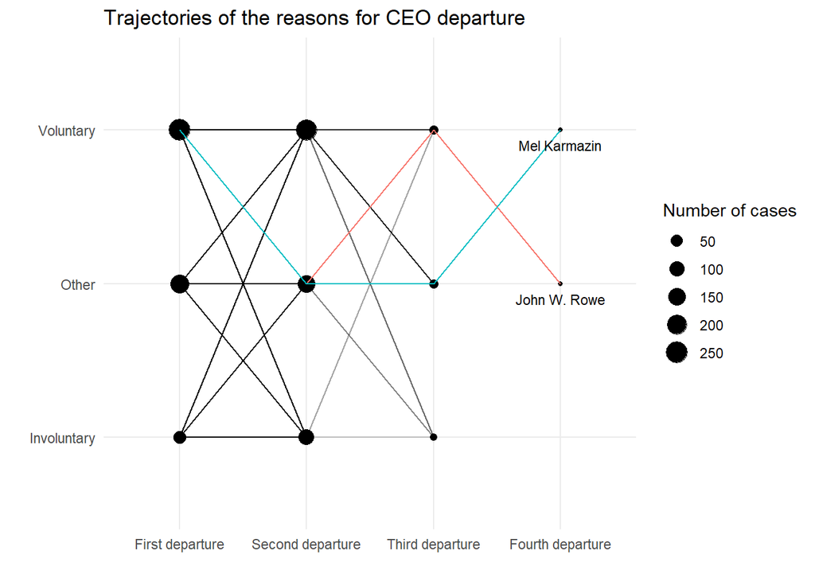

```r
#plot departure category with every change

ceo_changes_freq <- ceo_changes %>%
   count(departure_category, departure_no)

ceo_4_changes <- ceo_changes %>%
   filter(appears_al_twice  == 4)

ggplot(ceo_changes, aes(x = departure_no, y = departure_category)) +
   geom_line(aes(group = exec_fullname), alpha = 0.2) +
   geom_point(
      data = ceo_changes_freq,
      mapping = aes(size = n)) +
   geom_line(
      data = ceo_4_changes,
      mapping = aes(group = exec_fullname, color = exec_fullname),
      show.legend = FALSE) +
    geom_text_repel(
    data = filter(ceo_4_changes, departure_no == "Fourth departure"),
    mapping = aes(label = exec_fullname),
    nudge_y = -0.1,
    size = 3  # Adjust the size value as needed
      ) +
   labs(
      title = "Trajectories of the reasons for CEO departure",
      x = "",
      y = "",
      size = "Number of cases"
   ) +theme_minimal()
```

Just to dig in what is actual voluntary reason it is, will do below:

```r
#Map each exit of ceo with exact reasons
departures_reduced <- ceo_departures %>%
   filter(departure_code %in% 1:9) %>%
   mutate(
      departure_label = as.factor(recode(departure_code,
        `1` = "Death",
        '2'= "Illness",
         `3` = "Bad performance",
         `4` = "Legal",
         `5` = "Retired",
         `6` = "New opportunity",
         `7` = "Other",
        '8' = "Missing",
        '9'="Error")),
      fyear = lubridate::make_date(fyear)) %>%
   relocate(fyear, departure_label)
```

```r
#check which CEO names occurs more than 2 in the dataset
ceo_al_twice <- departures_reduced %>%
   group_by(exec_fullname) %>%
   mutate(appears_al_twice = n(), .after = departure_label) %>%
   filter(appears_al_twice > 1) %>%
   ungroup()
```

```r
#check the total count of CEOs occuring more than two
length(unique(ceo_al_twice$exec_fullname))
```

```
## [1] 479
```

```r
# Note: divide to get the unique values
table(ceo_al_twice$appears_al_twice) / c(2, 3, 4)
```

```
##
##   2   3   4
## 436  41   2
```

```r
#Map and plot each exit with departure category
ceo_changes <- ceo_al_twice %>%
   arrange(fyear) %>%
   group_by(exec_fullname) %>%
   mutate(departure_no = 1:n(), .after = departure_label,
          departure_no = fct_inorder(recode(departure_no,
             `1` = "First departure",
             `2` = "Second departure",
             `3` = "Third departure",
             `4` = "Fourth departure"))) %>%
   ungroup()
```

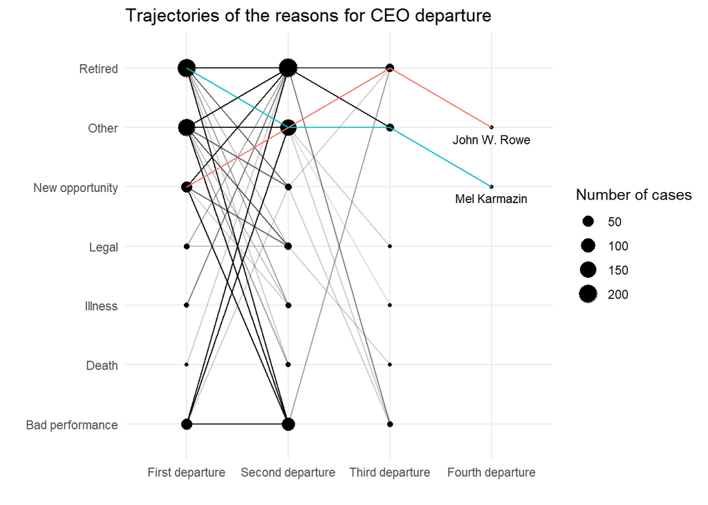

```r
#plot departure category with every change


ceo_changes_freq <- ceo_changes %>%
   count(departure_label, departure_no)

ceo_4_changes <- ceo_changes %>%
   filter(appears_al_twice  == 4)

ggplot(ceo_changes, aes(x = departure_no, y = departure_label)) +
   geom_line(aes(group = exec_fullname), alpha = 0.2) +
   geom_point(
      data = ceo_changes_freq,
      mapping = aes(size = n)) +
   geom_line(
      data = ceo_4_changes,
      mapping = aes(group = exec_fullname, color = exec_fullname),
      show.legend = FALSE) +
  geom_text_repel(
  data = filter(ceo_4_changes, departure_no == "Fourth departure"),
  mapping = aes(label = exec_fullname),
  nudge_y = -0.1,
  size = 3  # Adjust the size value as needed
      ) +
   labs(
      title = "Trajectories of the reasons for CEO departure",
      x = "",
      y = "",
      size = "Number of cases"
   ) +theme_minimal()
```

Two CEOs appear 4 times in the data set. None of them left for legal or bad performance reasons. Interestingly, retirement doesn’t seem to be “final”. Some CEO come back. All in all, there is no overwhelmingly clear connection but certainly some interesting insights.

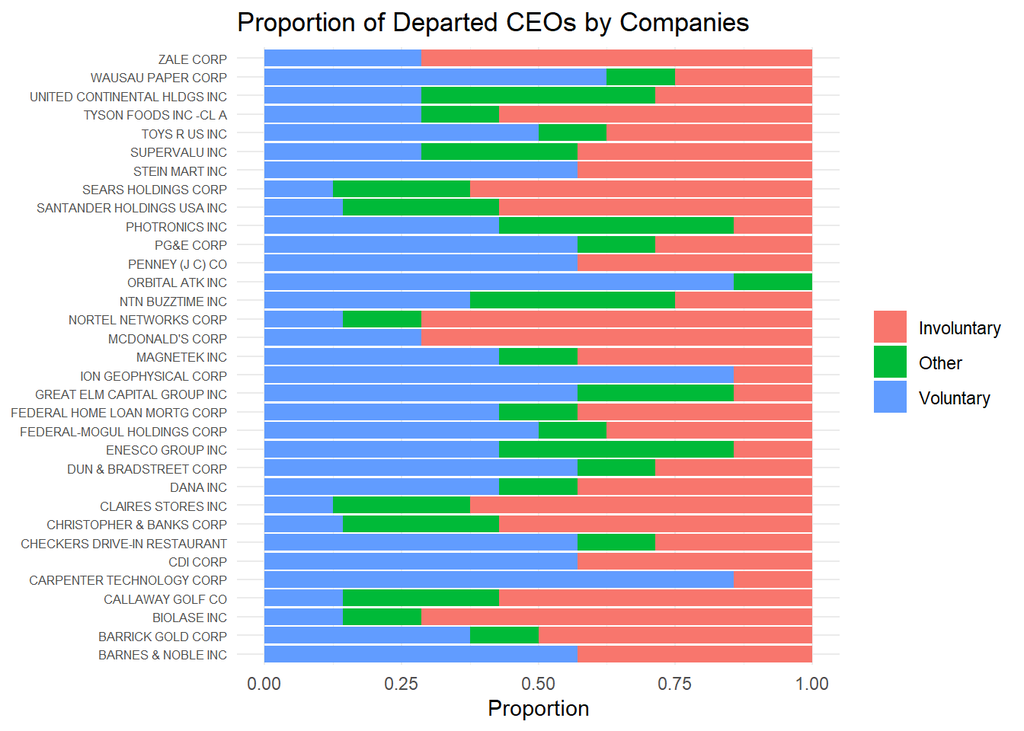

```r
#plot ceo departures across companies
top_companies <- ceo_departures %>%
    count(coname) %>%
    slice_max(n, n = 10) %>% pull(coname)

ceo_departures %>%
  filter(coname %in% top_companies) %>%
    ggplot(aes(coname, fill = departure_category)) +
    geom_bar(position = "fill") +
    coord_flip()+
    labs(title = "Proportion of Departed CEOs by Companies",
         x = NULL, y = "Proportion", fill = NULL) +  theme_minimal()+ theme(axis.text.y = element_text(size = 6))
```

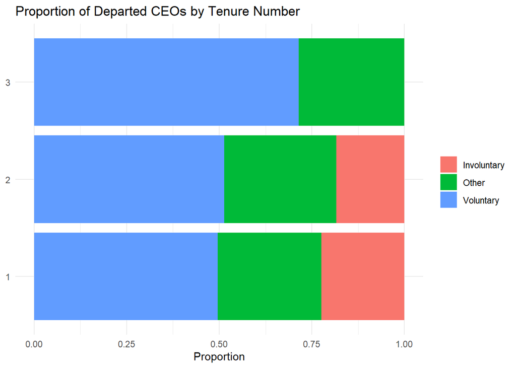

```r
#plot ceo departures by tenure
ceo_departures%>%
    ggplot(aes(tenure_no_ceodb, fill = departure_category)) +
    geom_bar(position = "fill") +
    coord_flip() +
    labs(title = "Proportion of Departed CEOs by Tenure Number",
         x = NULL, y = "Proportion", fill = NULL)+theme_minimal()
```

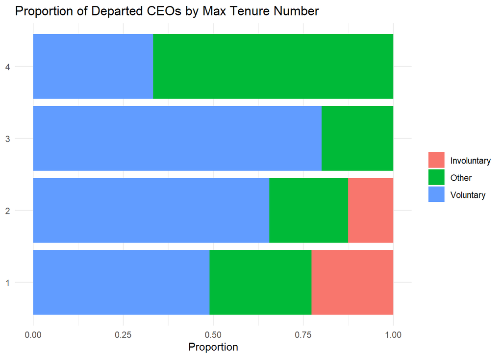

```r
#plot ceo departure by max tenure number
ceo_departures %>%
    ggplot(aes(max_tenure_ceodb, fill = departure_category)) +
    geom_bar(position = "fill") +
    coord_flip() +
    labs(title = "Proportion of Departed CEOs by Max Tenure Number",
         x = NULL, y = "Proportion", fill = NULL)+theme_minimal()
```

CORELATION ANALYSIS:

```r
library(dplyr)

# Select only numeric columns
numeric_data <- departures_raw %>% select_if(is.numeric)

# Remove rows with missing values in numeric columns
complete_cases <- complete.cases(numeric_data)
numeric_data_no_na <- numeric_data[complete_cases, ]

# Compute the correlation matrix
cor_matrix <- cor(numeric_data_no_na)

# Print the correlation matrix
print(cor_matrix)
```

```
##                      dismissal_dataset_id        gvkey        fyear
## dismissal_dataset_id           1.00000000  0.067077210  0.023317328
## gvkey                          0.06707721  1.000000000  0.321768147
## fyear                          0.02331733  0.321768147  1.000000000
## co_per_rol                     0.04309684  0.497332392  0.747539191
## departure_code                 0.01237810  0.008583880 -0.037432052
## ceo_dismissal                  0.01192048  0.015334123  0.050259822
## tenure_no_ceodb                0.09188626 -0.009564424  0.043343989
## max_tenure_ceodb               0.09018001 -0.013979701 -0.006371131
## fyear_gone                     0.01091894  0.167057836  0.520140553
## cik                            0.06203589  0.530823391  0.264411680
##                        co_per_rol departure_code ceo_dismissal tenure_no_ceodb
## dismissal_dataset_id  0.043096839    0.012378100    0.01192048     0.091886262
## gvkey                 0.497332392    0.008583880    0.01533412    -0.009564424
## fyear                 0.747539191   -0.037432052    0.05025982     0.043343989
## co_per_rol            1.000000000    0.001764455    0.06934485    -0.048776691
## departure_code        0.001764455    1.000000000   -0.67793340     0.010353555
## ceo_dismissal         0.069344846   -0.677933399    1.00000000    -0.025348305
## tenure_no_ceodb      -0.048776691    0.010353555   -0.02534831     1.000000000
## max_tenure_ceodb     -0.065360816    0.012191930   -0.05715891     0.693889367
## fyear_gone            0.390641902    0.006533440    0.01508269     0.019391254
## cik                   0.392111231    0.013885232    0.02573648    -0.009372235
##                      max_tenure_ceodb   fyear_gone          cik
## dismissal_dataset_id      0.090180007  0.010918937  0.062035891
## gvkey                    -0.013979701  0.167057836  0.530823391
## fyear                    -0.006371131  0.520140553  0.264411680
## co_per_rol               -0.065360816  0.390641902  0.392111231
## departure_code            0.012191930  0.006533440  0.013885232
## ceo_dismissal            -0.057158908  0.015082690  0.025736480
## tenure_no_ceodb           0.693889367  0.019391254 -0.009372235
## max_tenure_ceodb          1.000000000 -0.004821793 -0.009642779
## fyear_gone               -0.004821793  1.000000000  0.129812863
## cik                      -0.009642779  0.129812863  1.000000000
```

TEXT ANALYSIS:

```r
# Tokenize the 'notes' column into individual words
tokenized_data <- ceo_departures %>%
  unnest_tokens(word, notes)

# Remove stop words
tokenized_data <- tokenized_data %>%
  anti_join(stop_words)
# Calculate summary statistics for each word
word_stats <- tokenized_data %>%
  group_by(word) %>%
  summarize(
    mean_departure_code = mean(departure_code, na.rm = TRUE),
    sd_departure_code = sd(departure_code, na.rm = TRUE),
    n = n()
  )

# Display the summary statistics
print(word_stats)
```

```
## # A tibble: 24,847 × 4
##    word    mean_departure_code sd_departure_code     n
##    <chr>                 <dbl>             <dbl> <int>
##  1 0                      7                 0        2
##  2 0.00888                7                NA        1
##  3 0.01                   7                 0        3
##  4 0.05                   7                NA        1
##  5 0.09388                7                NA        1
##  6 0.1025                 7                NA        1
##  7 0.1818                 7                NA        1
##  8 0.19                   5                NA        1
##  9 0.2                    7                NA        1
## 10 0.20                   5.33              1.53     3
## # ℹ 24,837 more rows
```

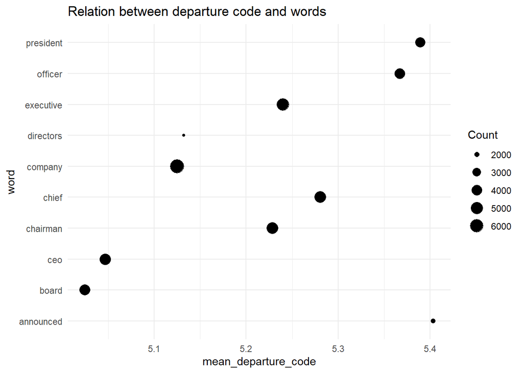

```r
# Select the top 30 words
top_30_words <- word_stats %>%
  top_n(10, wt = n)

# Create a scatter plot for the top 30 words
word_stats_plot <- ggplot(top_30_words, aes(x = mean_departure_code, y = word, size=n)) +
  geom_point() +
  labs(title = "Relation between departure code and words") +
  scale_size_continuous(name = "Count") +
  scale_color_viridis_c() +
  theme_minimal() +
  theme(axis.text.y = element_text(angle = 0, hjust = 1))

word_stats_plot
```

```r
log_odds_weighted_tb <- ceo_departures %>%

    # Extract most frequent words from notes
    unnest_tokens(word, notes) %>%
    anti_join(stop_words) %>%
    count(departure_category, word) %>%
    # slice_max(order_by = n, n = 100) %>%

    # Calculate how likely each word show up from dismissed CEO's notes
    bind_log_odds(departure_category, word, n) %>%
    arrange(-log_odds_weighted)
```

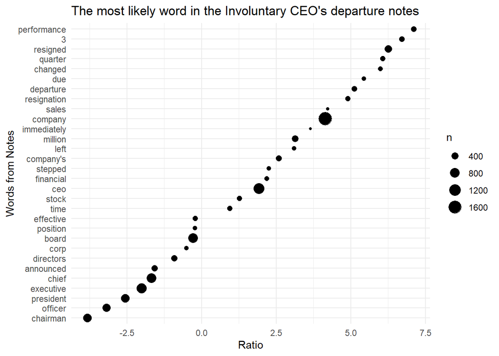

```r
# Select the category
log_odds_weighted_tb %>%
    filter(departure_category == "Involuntary") %>%
    slice_max(order_by = n, n = 30) %>%

    ggplot(aes(log_odds_weighted, fct_reorder(word, log_odds_weighted),size=n)) +
    geom_point(fill = "orange") +

    labs(title = "The most likely word in the Involuntary CEO's departure notes",
         y = "Words from Notes", x = "Ratio")+theme_minimal()
```

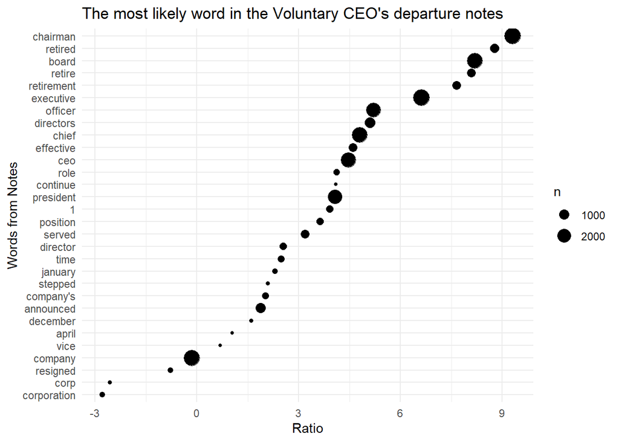

```r
log_odds_weighted_tb %>%
    filter(departure_category == "Voluntary") %>%
    slice_max(order_by = n, n = 30) %>%

    ggplot(aes(log_odds_weighted, fct_reorder(word, log_odds_weighted), size=n)) +
    geom_point(fill = "midnightblue") +

    labs(title = "The most likely word in the Voluntary CEO's departure notes",
         y = "Words from Notes", x = "Ratio")+theme_minimal()
```

```r
#view data
ceo_departures
```

```
## # A tibble: 7,590 × 10
##    dismissal_dataset_id coname                fyear exec_fullname departure_code
##    <fct>                <fct>                 <dbl> <fct>                  <dbl>
##  1 559043               SONICBLUE INC          2002 L. Gregory B…              7
##  2 12                   AMERICAN AIRLINES GR…  1997 Robert L. Cr…              5
##  3 13                   AMERICAN AIRLINES GR…  2002 Donald J. Ca…              3
##  4 31                   ABBOTT LABORATORIES    1998 Duane L. Bur…              5
##  5 43                   ADVANCED MICRO DEVIC…  2001 Walter Jerem…              5
##  6 51                   AETNA INC              1997 Ronald Edwar…              5
##  7 61                   AHMANSON (H F) & CO    1993 Richard H. D…              5
##  8 63                   AHMANSON (H F) & CO    1997 Charles R. R…              7
##  9 65                   AIR PRODUCTS & CHEMI…  2000 Harold A. Wa…              5
## 10 75                   ALBERTO-CULVER CO      1993 Leonard H. L…              5
## # ℹ 7,580 more rows
## # ℹ 5 more variables: tenure_no_ceodb <fct>, max_tenure_ceodb <fct>,
## #   fyear_gone <fct>, notes <chr>, departure_category <fct>
```

MODEL BUILDING AND EVALUATION:

MODEL 1: GENERALIZED LINEAR MODEL

```r
#preapre data for model1
departures1 <- departures_raw %>%
  filter(departure_code < 8) %>%
  mutate(involuntary = if_else(departure_code %in% 3:4, "involuntary", "other")) %>%
  filter(fyear > 1995, fyear < 2019)
departures1
```

```
## # A tibble: 6,893 × 20
##    dismissal_dataset_id coname              gvkey fyear co_per_rol exec_fullname
##                   <dbl> <chr>               <dbl> <dbl>      <dbl> <chr>
##  1               559043 SONICBLUE INC       27903  2002         -1 L. Gregory B…
##  2                   12 AMERICAN AIRLINES …  1045  1997          1 Robert L. Cr…
##  3                   13 AMERICAN AIRLINES …  1045  2002          3 Donald J. Ca…
##  4                   31 ABBOTT LABORATORIES  1078  1998          6 Duane L. Bur…
##  5                   43 ADVANCED MICRO DEV…  1161  2001         11 Walter Jerem…
##  6                   51 AETNA INC            1177  1997         16 Ronald Edwar…
##  7                   63 AHMANSON (H F) & CO  1194  1997         22 Charles R. R…
##  8                   65 AIR PRODUCTS & CHE…  1209  2000         28 Harold A. Wa…
##  9                   76 ALBERTO-CULVER CO    1239  2007         34 Howard B. Be…
## 10                   78 ALBERTSON'S INC      1240  2000         38 Gary Glenn M…
## # ℹ 6,883 more rows
## # ℹ 14 more variables: departure_code <dbl>, ceo_dismissal <dbl>,
## #   interim_coceo <chr>, tenure_no_ceodb <dbl>, max_tenure_ceodb <dbl>,
## #   fyear_gone <dbl>, leftofc <dttm>, still_there <chr>, notes <chr>,
## #   sources <chr>, eight_ks <chr>, cik <dbl>, `_merge` <chr>, involuntary <chr>
```

```r
df <- departures1 %>%
  count(fyear, involuntary) %>%
  pivot_wider(names_from = involuntary, values_from = n)

mod <- glm(cbind(involuntary, other) ~ fyear, data = df, family = "binomial")
summary(mod)
```

```
##
## Call:
## glm(formula = cbind(involuntary, other) ~ fyear, family = "binomial",
##     data = df)
##
## Coefficients:
##              Estimate Std. Error z value Pr(>|z|)
## (Intercept) -34.14612    8.95122  -3.815 0.000136 ***
## fyear         0.01633    0.00446   3.662 0.000250 ***
## ---
## Signif. codes:  0 '***' 0.001 '**' 0.01 '*' 0.05 '.' 0.1 ' ' 1
##
## (Dispersion parameter for binomial family taken to be 1)
##
##     Null deviance: 80.017  on 22  degrees of freedom
## Residual deviance: 66.578  on 21  degrees of freedom
## AIC: 201.67
##
## Number of Fisher Scoring iterations: 4
```

```r
#view the dataframe
df
```

```
## # A tibble: 23 × 3
##    fyear involuntary other
##    <dbl>       <int> <int>
##  1  1996          42   273
##  2  1997          52   274
##  3  1998          42   304
##  4  1999          58   332
##  5  2000          78   282
##  6  2001          64   163
##  7  2002          73   183
##  8  2003          45   217
##  9  2004          59   262
## 10  2005          61   212
## # ℹ 13 more rows
```

```r
# Count the occurrences of 'fyear' and 'involuntary' in the 'departures1' dataset
df <- departures1 %>% count(fyear,involuntary) %>%

# Pivot the data to wide format with 'involuntary' as column names and 'n' as values
  pivot_wider(names_from = involuntary , values_from = n)

# Fit a generalized linear model (GLM) using binomial family
mod <- glm(cbind(involuntary, other) ~ fyear, data = df, family = "binomial")

# Display a summary of the fitted model
summary(mod)
```

```
##
## Call:
## glm(formula = cbind(involuntary, other) ~ fyear, family = "binomial",
##     data = df)
##
## Coefficients:
##              Estimate Std. Error z value Pr(>|z|)
## (Intercept) -34.14612    8.95122  -3.815 0.000136 ***
## fyear         0.01633    0.00446   3.662 0.000250 ***
## ---
## Signif. codes:  0 '***' 0.001 '**' 0.01 '*' 0.05 '.' 0.1 ' ' 1
##
## (Dispersion parameter for binomial family taken to be 1)
##
##     Null deviance: 80.017  on 22  degrees of freedom
## Residual deviance: 66.578  on 21  degrees of freedom
## AIC: 201.67
##
## Number of Fisher Scoring iterations: 4
```

```r
# Tidy and exponentiate the coefficients of the fitted model 'mod'
tidy(mod, exponentiate = TRUE)
```

```
## # A tibble: 2 × 5
##   term        estimate std.error statistic  p.value
##   <chr>          <dbl>     <dbl>     <dbl>    <dbl>
## 1 (Intercept) 1.48e-15   8.95        -3.81 0.000136
## 2 fyear       1.02e+ 0   0.00446      3.66 0.000250
```

When we use exponentiate = TRUE, we get the model coefficients on the linear scale instead of the logistic scale.

What we want to do is fit a model like this a whole bunch of times, instead of just once. Let’s create bootstrap resamples.

```r
# Set a seed for reproducibility
set.seed(123)

# Create bootstrap samples using the 'bootstraps' function from
# The number of times the resampling is done is set to 1000
ceo_folds <- bootstraps(departures1, times = 1e3)

# Display the resulting bootstrap samples
ceo_folds
```

```
## # Bootstrap sampling
## # A tibble: 1,000 × 2
##    splits              id
##    <list>              <chr>
##  1 <split [6893/2531]> Bootstrap0001
##  2 <split [6893/2543]> Bootstrap0002
##  3 <split [6893/2490]> Bootstrap0003
##  4 <split [6893/2536]> Bootstrap0004
##  5 <split [6893/2528]> Bootstrap0005
##  6 <split [6893/2519]> Bootstrap0006
##  7 <split [6893/2492]> Bootstrap0007
##  8 <split [6893/2532]> Bootstrap0008
##  9 <split [6893/2569]> Bootstrap0009
## 10 <split [6893/2605]> Bootstrap0010
## # ℹ 990 more rows
```

Now we need to make a function to count up the departures by year and type, fit our model, and return the coefficients we want.

```r
# Define a function named 'fit_binom' for fitting a binomial generalized linear model (GLM) to a subset of data.
fit_binom <- function(split) {

  # Extract the analysis data from the split and perform data manipulation
  df <- analysis(split) %>%
    count(fyear, involuntary) %>%
    pivot_wider(names_from = involuntary, values_from = n)

   # Fit a binomial generalized linear model (GLM) using the pivoted data
   mod <- glm(cbind(involuntary, other) ~ fyear, data = df, family = "binomial")
   # Extract and tidy the model coefficients, exponentiate for interpretation
   tidy(mod, exponentiate = TRUE)
}
```

We can apply that function to all our bootstrap resamples with purrr::map().

```r
# Apply the 'fit_binom' function to each split in 'ceo_folds' using 'map'
boot_models <- ceo_folds %>% mutate(coef_info = map(splits, fit_binom))
boot_models
```

```
## # Bootstrap sampling
## # A tibble: 1,000 × 3
##    splits              id            coef_info
##    <list>              <chr>         <list>
##  1 <split [6893/2531]> Bootstrap0001 <tibble [2 × 5]>
##  2 <split [6893/2543]> Bootstrap0002 <tibble [2 × 5]>
##  3 <split [6893/2490]> Bootstrap0003 <tibble [2 × 5]>
##  4 <split [6893/2536]> Bootstrap0004 <tibble [2 × 5]>
##  5 <split [6893/2528]> Bootstrap0005 <tibble [2 × 5]>
##  6 <split [6893/2519]> Bootstrap0006 <tibble [2 × 5]>
##  7 <split [6893/2492]> Bootstrap0007 <tibble [2 × 5]>
##  8 <split [6893/2532]> Bootstrap0008 <tibble [2 × 5]>
##  9 <split [6893/2569]> Bootstrap0009 <tibble [2 × 5]>
## 10 <split [6893/2605]> Bootstrap0010 <tibble [2 × 5]>
## # ℹ 990 more rows
```

What did we find? We can compute bootstrap confidence intervals with int_pctl().

```r
#Calculate percentile intervals for the model coefficients using 'int_pctl'
percentile_intervals <- int_pctl(boot_models, coef_info)

# Display the resulting percentile intervals
percentile_intervals
```

```
## # A tibble: 2 × 6
##   term          .lower  .estimate       .upper .alpha .method
##   <chr>          <dbl>      <dbl>        <dbl>  <dbl> <chr>
## 1 (Intercept) 1.03e-22 0.00000156 0.0000000380   0.05 percentile
## 2 fyear       1.01e+ 0 1.02       1.02           0.05 percentile
```

We can also visualize the results as well.

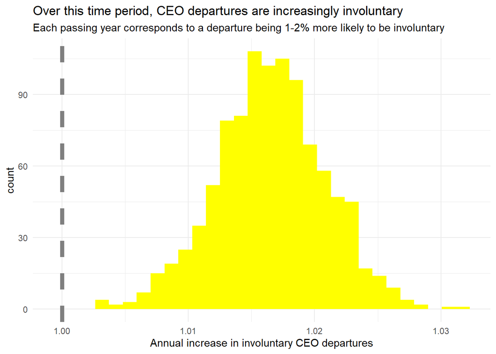

```r
# Extract information from each bootstrap model and unnest the coefficients
# Filter for the term "fyear" and create a histogram using ggplot
boot_models %>%
  unnest(coef_info) %>%
  filter(term == "fyear") %>%
  ggplot(aes(estimate)) +
  geom_vline(xintercept = 1, lty = 2, color = "gray50", size = 2) +
  geom_histogram(fill="yellow") +
  labs(
    x = "Annual increase in involuntary CEO departures",
    title = "Over this time period, CEO departures are increasingly involuntary",
    subtitle = "Each passing year corresponds to a departure being 1-2% more likely to be involuntary"
  )+theme_minimal()
```

MODEL 2:

PREPARE THE DATA FOR MODEL:

```r
#remove unwanted features
data <- ceo_departures %>%
  select(-coname, -exec_fullname, -departure_code,-fyear_gone)
```

```r
data
```

```
## # A tibble: 7,590 × 6
##    dismissal_dataset_id fyear tenure_no_ceodb max_tenure_ceodb notes
##    <fct>                <dbl> <fct>           <fct>            <chr>
##  1 559043                2002 1               1                "Ballard took ov…
##  2 12                    1997 1               1                "Mr. Crandall, t…
##  3 13                    2002 1               1                "Donald Carty re…
##  4 31                    1998 1               1                "The top two exe…
##  5 43                    2001 1               1                "Advanced Micro …
##  6 51                    1997 1               1                "Joseph T. Sebas…
##  7 61                    1993 1               1                "Richard H. Deih…
##  8 63                    1997 1               1                "In March, Ahman…
##  9 65                    2000 1               1                "Air Products an…
## 10 75                    1993 1               1                "Leonard Lavin b…
## # ℹ 7,580 more rows
## # ℹ 1 more variable: departure_category <fct>
```

```r
# data <- sample_n(data, 100)

# Set a seed for reproducibility
set.seed(123)

# Split the 'data' into training and testing
departure_split <- initial_split(data, strata = departure_category)

# Extract the training and testing sets from the split
departure_train <- training(departure_split)
departure_test <- testing(departure_split)

# Set a different seed for cross-validation
set.seed(234)

# Create cross-validation folds from the training
departure_folds <- vfold_cv(departure_train, strata = departure_category)

# Display the resulting cross-validation folds
departure_folds
```

```
## #  10-fold cross-validation using stratification
## # A tibble: 10 × 2
##    splits             id
##    <list>             <chr>
##  1 <split [5121/570]> Fold01
##  2 <split [5121/570]> Fold02
##  3 <split [5121/570]> Fold03
##  4 <split [5121/570]> Fold04
##  5 <split [5122/569]> Fold05
##  6 <split [5122/569]> Fold06
##  7 <split [5122/569]> Fold07
##  8 <split [5122/569]> Fold08
##  9 <split [5123/568]> Fold09
## 10 <split [5124/567]> Fold10
```

```r
# Create a recipe for modeling departure_category using the departure_train data
departures_rec <-
    recipe(departure_category ~ ., data = departure_train) %>%
  # Update the role of 'dismissal_dataset_id' to "id"
    update_role(dismissal_dataset_id, new_role = "id") %>%

  # Tokenize the 'notes' column
    step_tokenize(notes) %>%

  # Remove stopwords from the 'notes' column
    step_stopwords(notes) %>%

  # Limit the number of tokens to 100 in the 'notes' column
    step_tokenfilter(notes, max_tokens = 100) %>%

  # Apply TF-IDF transformation to the 'notes' column
    step_tfidf(notes) %>%

  # Create dummy variables for all nominal predictors
    step_dummy(all_nominal_predictors())

# Prepare the recipe
departures_rec %>% prep() %>% juice() %>% glimpse()
```

```
## Rows: 5,691
## Columns: 108
## $ dismissal_dataset_id    <fct> 13, 78, 85, 88, 119, 162, 198, 243, 244, 256, …
## $ fyear                   <dbl> 2002, 2000, 1998, 1993, 1995, 2004, 1998, 1993…
## $ departure_category      <fct> Involuntary, Involuntary, Involuntary, Involun…
## $ tfidf_notes_1           <dbl> 0, 0, 0, 0, 0, 0, 0, 0, 0, 0, 0, 0, 0, 0, 0, 0…
## $ tfidf_notes_1994        <dbl> 0.0000000, 0.0000000, 0.0000000, 0.0000000, 0.…
## $ tfidf_notes_1995        <dbl> 0.0000000, 0.0000000, 0.1786094, 0.0000000, 0.…
## $ tfidf_notes_1996        <dbl> 0.00000000, 0.00000000, 0.00000000, 0.00000000…
## $ tfidf_notes_1997        <dbl> 0.0000000, 0.0000000, 0.3478837, 0.0000000, 0.…
## $ tfidf_notes_1998        <dbl> 0.0000000, 0.0000000, 0.3429937, 0.0000000, 0.…
## $ tfidf_notes_1999        <dbl> 0.0000000, 0.2848392, 0.0000000, 0.0000000, 0.…
## $ tfidf_notes_2000        <dbl> 0.0000000, 0.1480028, 0.1741209, 0.0000000, 0.…
## $ tfidf_notes_2001        <dbl> 0.0000000, 0.0000000, 0.0000000, 0.0000000, 0.…
## $ tfidf_notes_2007        <dbl> 0, 0, 0, 0, 0, 0, 0, 0, 0, 0, 0, 0, 0, 0, 0, 0…
```

[output cut: 95 more lines]

```r
# Prepare the 'departures_rec' recipe
# Apply the recipe transformations to the data and extract the first tidy summary
prep(departures_rec) %>%
  tidy(number = 1)
```

```
## # A tibble: 1 × 3
##   terms value id
##   <chr> <chr> <chr>
## 1 notes words tokenize_wUwQE
```

```r
# Apply the 'departures_rec' recipe to prepare the data
# Extract a tidy summary of the prepared data, considering only the first row
tidy_result <- departures_rec %>%
  prep() %>%
  tidy(number = 1) %>%
  filter(terms == "..new")
```

```r
# Define an XGBoost specification for a classification model
xgb_spec <-
  boost_tree(
    trees = tune(), # Number of trees to be tuned
    min_n = tune(), # Minimum number of observations in a node to be tuned
    mtry = tune(),  # Number of variables randomly sampled as candidates at each split to be tuned
    learn_rate = 0.01 # Learning rate set to 0.01
  ) %>%
  set_engine("xgboost") %>%
  set_mode("classification")

# Create a workflow using the defined XGBoost specification and the 'departures_rec'
xgb_wf <- workflow(departures_rec, xgb_spec)
```

```r
library(finetune)

# Register a parallel backend for parallel processing with 3 cores
doParallel::registerDoParallel(cores=3)

# Set a seed for reproducibility
set.seed(345)

# Tune the parameters of the XGBoost model using a grid search
# with 5 iterations per combination of hyperparameters
xgb_rs <- tune_grid(
  xgb_wf, # XGBoost workflow to be tuned
  resamples = departure_folds, # Cross-validation folds
  grid = 5, # Number of iterations per combination of hyperparameters
  control = control_grid(verbose = TRUE, save_pred = TRUE) # Grid search
)
```

```
## i Creating pre-processing data to finalize unknown parameter: mtry
```

```r
# Display the results of tuning
xgb_rs
```

```
## # Tuning results
## # 10-fold cross-validation using stratification
## # A tibble: 10 × 5
##    splits             id     .metrics          .notes           .predictions
##    <list>             <chr>  <list>            <list>           <list>
##  1 <split [5121/570]> Fold01 <tibble [10 × 7]> <tibble [0 × 3]> <tibble>
##  2 <split [5121/570]> Fold02 <tibble [10 × 7]> <tibble [0 × 3]> <tibble>
##  3 <split [5121/570]> Fold03 <tibble [10 × 7]> <tibble [0 × 3]> <tibble>
##  4 <split [5121/570]> Fold04 <tibble [10 × 7]> <tibble [0 × 3]> <tibble>
##  5 <split [5122/569]> Fold05 <tibble [10 × 7]> <tibble [0 × 3]> <tibble>
##  6 <split [5122/569]> Fold06 <tibble [10 × 7]> <tibble [0 × 3]> <tibble>
##  7 <split [5122/569]> Fold07 <tibble [10 × 7]> <tibble [0 × 3]> <tibble>
##  8 <split [5122/569]> Fold08 <tibble [10 × 7]> <tibble [0 × 3]> <tibble>
##  9 <split [5123/568]> Fold09 <tibble [10 × 7]> <tibble [0 × 3]> <tibble>
## 10 <split [5124/567]> Fold10 <tibble [10 × 7]> <tibble [0 × 3]> <tibble>
```

```r
#collect the metrics
collect_metrics(xgb_rs)
```

```
## # A tibble: 10 × 9
##     mtry trees min_n .metric  .estimator  mean     n std_err .config
##    <int> <int> <int> <chr>    <chr>      <dbl> <int>   <dbl> <chr>
##  1    22   606    28 accuracy multiclass 0.735    10 0.00485 Preprocessor1_Mode…
##  2    22   606    28 roc_auc  hand_till  0.879    10 0.00323 Preprocessor1_Mode…
##  3    25  1196    24 accuracy multiclass 0.748    10 0.00436 Preprocessor1_Mode…
##  4    25  1196    24 roc_auc  hand_till  0.884    10 0.00372 Preprocessor1_Mode…
##  5    43  1331    37 accuracy multiclass 0.746    10 0.00536 Preprocessor1_Mode…
##  6    43  1331    37 roc_auc  hand_till  0.885    10 0.00376 Preprocessor1_Mode…
##  7    70  1641     7 accuracy multiclass 0.751    10 0.00318 Preprocessor1_Mode…
##  8    70  1641     7 roc_auc  hand_till  0.884    10 0.00351 Preprocessor1_Mode…
##  9    98   194    13 accuracy multiclass 0.719    10 0.00378 Preprocessor1_Mode…
## 10    98   194    13 roc_auc  hand_till  0.860    10 0.00388 Preprocessor1_Mode…
```

Finalize Workflow:

```r
# Finalize the XGBoost workflow by selecting the best hyperparameters based on accuracy
# and fitting the model on the entire training data
xgb_last <- xgb_wf %>%
  finalize_workflow(select_best(xgb_rs, "accuracy")) %>%
  last_fit(departure_split)

# Display the results of the final model fit
xgb_last
```

```
## # Resampling results
## # Manual resampling
## # A tibble: 1 × 6
##   splits              id               .metrics .notes   .predictions .workflow
##   <list>              <chr>            <list>   <list>   <list>       <list>
## 1 <split [5691/1899]> train/test split <tibble> <tibble> <tibble>     <workflow>
```

```r
#collect metrics
collect_metrics(xgb_last)
```

```
## # A tibble: 2 × 4
##   .metric  .estimator .estimate .config
##   <chr>    <chr>          <dbl> <chr>
## 1 accuracy multiclass     0.764 Preprocessor1_Model1
## 2 roc_auc  hand_till      0.892 Preprocessor1_Model1
```

```r
#confusion matrix
collect_predictions(xgb_last) %>%
    conf_mat(departure_category, .pred_class)
```

```
##              Truth
## Prediction    Involuntary Other Voluntary
##   Involuntary         250    46        95
##   Other                47   395        42
##   Voluntary           127    91       806
```

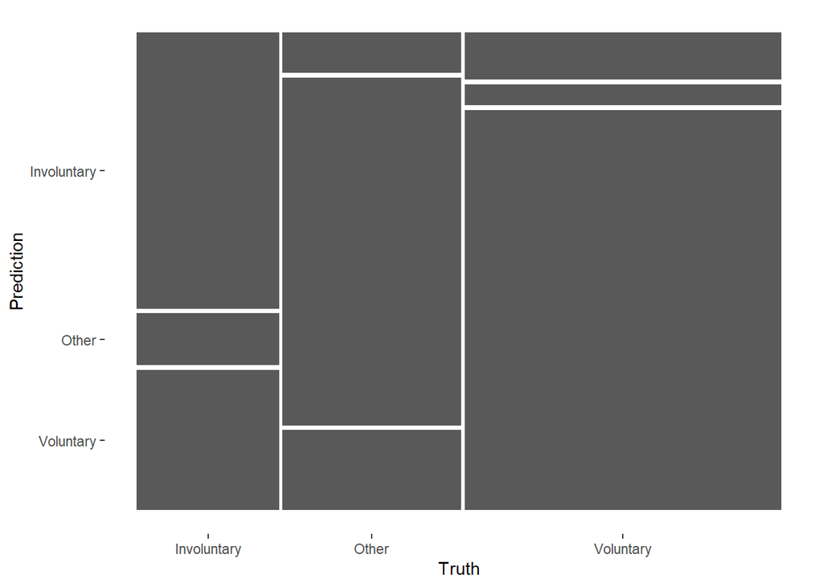

```r
#plot the confusion matrix
collect_predictions(xgb_last) %>%
    conf_mat(departure_category, .pred_class) %>% autoplot
```

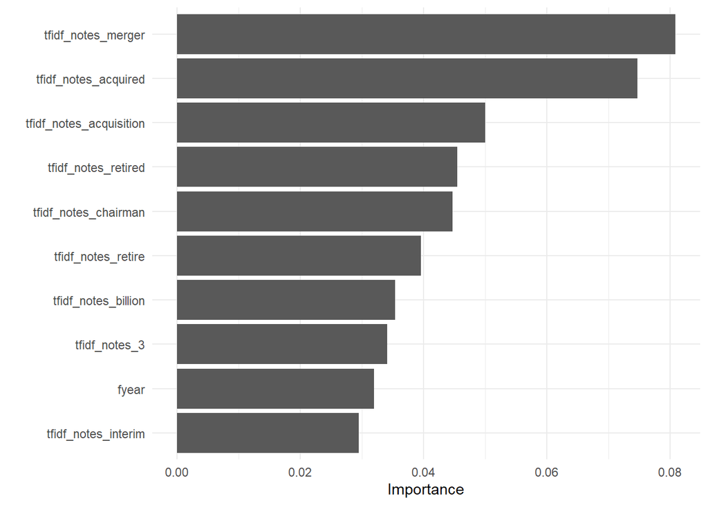

```r
#variable importance plot
library(vip)
xgb_last %>%
  extract_fit_engine() %>%
  vip()+theme_minimal()
```

MODEL 3: SUPPORT VECTOR MACHINE:

```r
#prepare data for model 3
data_filtered <- data[data$departure_category != "Other",]
```

```r
# data <- sample_n(data, 100)

library(tidymodels)

#set reproducibility
set.seed(123)

#split the data
departure_split <- initial_split(data_filtered, strata = departure_category)

#extract train and test data
departure_train <- training(departure_split)
departure_test <- testing(departure_split)

#set reproducibility
set.seed(234)
departure_folds <- vfold_cv(departure_train, strata = departure_category)
departure_folds
```

```
## #  10-fold cross-validation using stratification
## # A tibble: 10 × 2
##    splits             id
##    <list>             <chr>
##  1 <split [3687/410]> Fold01
##  2 <split [3687/410]> Fold02
##  3 <split [3687/410]> Fold03
##  4 <split [3687/410]> Fold04
##  5 <split [3687/410]> Fold05
##  6 <split [3687/410]> Fold06
##  7 <split [3687/410]> Fold07
##  8 <split [3687/410]> Fold08
##  9 <split [3688/409]> Fold09
## 10 <split [3689/408]> Fold10
```

```r
library(recipes)
library(rsample)

# Feature engineering
## Creating preprocessing recipe for predicting voluntary/involuntary departures
departures_rec <-  recipe(departure_category ~ notes, data = departure_train) %>%
  # Splitting the "notes" variable into individual tokens (words)
  step_tokenize(notes) %>%
  # Limiting number of tokens used in model
  step_tokenfilter(notes, max_tokens = 1000) %>%
  # Weighing tokens by tf-idf
  step_tfidf(notes) %>%
  # Normalising numeric predictors
  step_normalize(all_numeric_predictors())
```

```r
# Specifying the machine learning model
## This model will use a linear Support Vector Machine (SVM)
svm_spec <- svm_linear() %>%
  set_mode("classification") %>%
  set_engine("LiblineaR")
```

```r
# Combining the feature engineering recipe and model spec to create a workflow
departures_wf <- workflow() %>%
  add_recipe(departures_rec) %>%
  add_model(svm_spec)
```

```r
# Printing the workflow
departures_wf
```

```
## ══ Workflow ════════════════════════════════════════════════════════════════════
## Preprocessor: Recipe
## Model: svm_linear()
##
## ── Preprocessor ────────────────────────────────────────────────────────────────
## 4 Recipe Steps
##
## • step_tokenize()
## • step_tokenfilter()
## • step_tfidf()
## • step_normalize()
##
## ── Model ───────────────────────────────────────────────────────────────────────
## Linear Support Vector Machine Model Specification (classification)
##
## Computational engine: LiblineaR
```

```r
# Selecting the metrics used for modelling
departures_metrics <- metric_set(accuracy, recall, precision)
```

```r
# Setting up parallel processing
library(parallel)
library(doParallel)
cl <- makePSOCKcluster(detectCores() - 1)
registerDoParallel(cl)
```

```r
library(LiblineaR)
# Setting seed for reproducibility
set.seed(100)
# Fitting models using resampling
svm_results <- fit_resamples(
  departures_wf, # Specifying workflow
  departure_folds, # Specifying cross validation folds
  metrics = departures_metrics, # Metrics used for modelling
  control = control_resamples(save_pred = TRUE) # Saving predictions for confusion matrix
)
```

[output not shown]

[output not shown]

```r
# Printing performance metrics of SVM model
collect_metrics(svm_results)
```

```
## # A tibble: 3 × 6
##   .metric   .estimator  mean     n std_err .config
##   <chr>     <chr>      <dbl> <int>   <dbl> <chr>
## 1 accuracy  multiclass 0.804    10 0.00500 Preprocessor1_Model1
## 2 precision macro      0.771    10 0.00558 Preprocessor1_Model1
## 3 recall    macro      0.782    10 0.00449 Preprocessor1_Model1
```

```r
# Setting seed for reproducibility
set.seed(100)

# Fitting the final model
final_fitted <- last_fit(departures_wf, departure_split,
                      metrics = departures_metrics)
```

[output not shown]

[output not shown]

```r
# Printing performance metrics of final fitted model
collect_metrics(final_fitted)
```

```
## # A tibble: 3 × 4
##   .metric   .estimator .estimate .config
##   <chr>     <chr>          <dbl> <chr>
## 1 accuracy  multiclass     0.805 Preprocessor1_Model1
## 2 recall    macro          0.790 Preprocessor1_Model1
## 3 precision macro          0.772 Preprocessor1_Model1
```

```r
# Printing the confusion matrix of the model trained using the 10-fold cv
## training data
svm_results %>%
  conf_mat_resampled(tidy = FALSE)
```

```
##             Involuntary Other Voluntary
## Involuntary        92.0   0.0      45.4
## Other               0.0   0.0       0.0
## Voluntary          34.9   0.0     237.4
```

```r
# Printing the confusion matrix of the final fitted model
collect_predictions(final_fitted) %>%
  conf_mat(departure_category, .pred_class)
```

```
##              Truth
## Prediction    Involuntary Other Voluntary
##   Involuntary         319     0       162
##   Other                 0     0         0
##   Voluntary           105     0       781
```

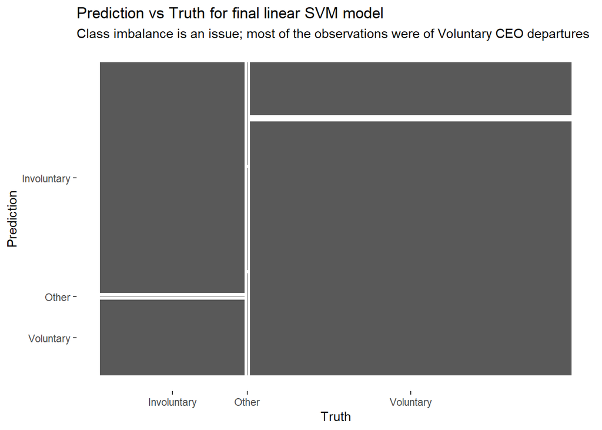

```r
# Visualising confusion matrix of the final fitted model
collect_predictions(final_fitted) %>%
  conf_mat(departure_category, .pred_class) %>%
  autoplot() +
  labs(title = "Prediction vs Truth for final linear SVM model",
       subtitle = "Class imbalance is an issue; most of the observations were of Voluntary CEO departures")
```

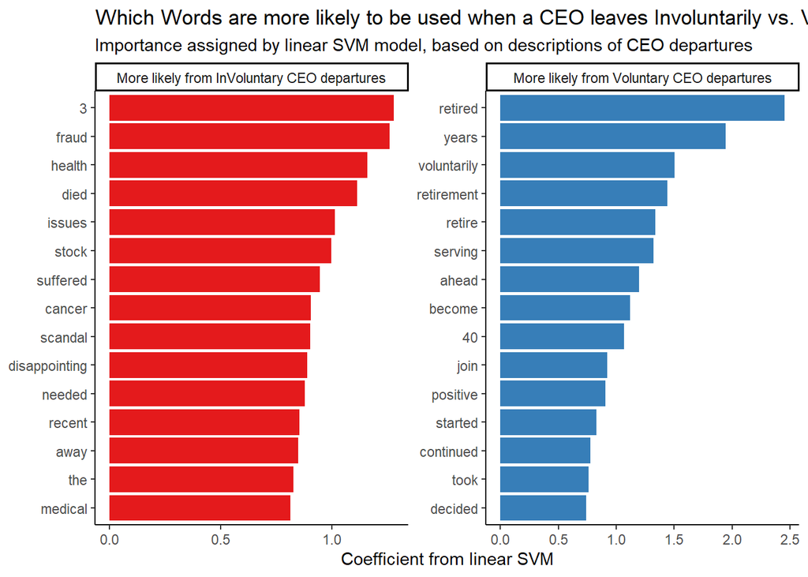

```r
# Extracting model fit
departures_fit <- pull_workflow_fit(final_fitted$.workflow[[1]])

# Visualising the most important words for predicting whether a CEO departure
## was voluntary
tidy(departures_fit) %>%
  filter(term != "Bias") %>%
  group_by(sign = estimate > 0) %>%
  slice_max(abs(estimate), n = 15) %>%
  ungroup() %>%
  mutate(term = str_remove(term, "tfidf_notes_"), # Tidying terms
         sign = ifelse(sign, "More likely from InVoluntary CEO departures",
                       "More likely from Voluntary CEO departures")) %>%
  ggplot(aes(abs(estimate), fct_reorder(term, abs(estimate)), fill = sign)) +
  geom_col(show.legend = FALSE) +
  facet_wrap(~sign, scales = "free") +
  labs(x = "Coefficient from linear SVM", y = NULL) +
  scale_fill_brewer(palette = "Set1") +
  theme_classic() +
  labs(titles = "Which Words are more likely to be used when a CEO leaves Involuntarily vs. Voluntarily?",
       subtitle = "Importance assigned by linear SVM model, based on descriptions of CEO departures")
```